# Simulation and Data Distributions

## Exercise

Examine the orchis2 data object. Here are column data frame with a response variable `flower` and predictor variable `site`. Produce a histogram for the `site: 'sprayed'`. Now overlay a density plot over it.

```r
orchis2 <- read.csv('orchis2.csv')
orchis2
```

| flower | site |
| --- | --- |
| 7 | closed |
| 8 | closed |
| 6 | closed |
| 9 | closed |
| 10 | closed |
| 11 | closed |
| 7 | closed |
| 8 | closed |
| 10 | closed |
| 9 | closed |

[output cut: 20 more lines]

Histogram of frequency distribution for `site: sprayed`

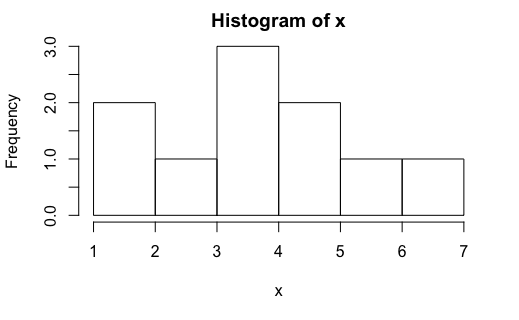

```r
sprayed <- subset(orchis2, orchis2$site == 'sprayed')
x <- sprayed$flower
hist(x)
```

Histogram of density distribution for `site: sprayed`

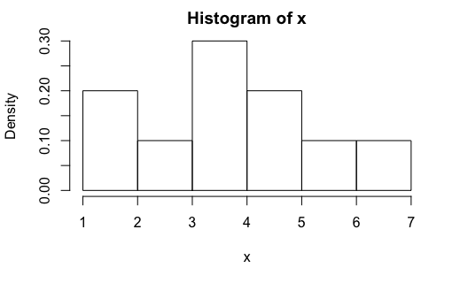

```r
hist(x, freq = F)
```

Histogram of density distribution for `site: sprayed` with overlay density plot.

```r
hist(x, freq = F)
dens_x <- density(x)
lines(dens_x, lty = 'dashed')
```

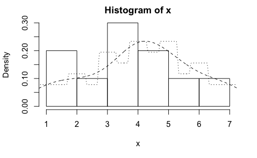

```r
dens_x_rect <- density(x, k = 'rectangular')
lines(dens_x_rect, lty = 'dotted')
```

## Other Datasets

Other datasets available for public use that comes bundled with R using the `datasets` library can be found from the link beneath.

https://stat.ethz.ch/R-manual/R-devel/library/datasets/html/00Index.html

An example of using the `mtcars` dataset.

```r
library(datasets)
head(mtcars)
```

|  | mpg | cyl | disp | hp | drat | wt | qsec | vs | am | gear | carb |
| --- | --- | --- | --- | --- | --- | --- | --- | --- | --- | --- | --- |
| Mazda RX4 | 21.0 | 6 | 160 | 110 | 3.90 | 2.620 | 16.46 | 0 | 1 | 4 | 4 |
| Mazda RX4 Wag | 21.0 | 6 | 160 | 110 | 3.90 | 2.875 | 17.02 | 0 | 1 | 4 | 4 |
| Datsun 710 | 22.8 | 4 | 108 | 93 | 3.85 | 2.320 | 18.61 | 1 | 1 | 4 | 1 |
| Hornet 4 Drive | 21.4 | 6 | 258 | 110 | 3.08 | 3.215 | 19.44 | 1 | 0 | 3 | 1 |
| Hornet Sportabout | 18.7 | 8 | 360 | 175 | 3.15 | 3.440 | 17.02 | 0 | 0 | 3 | 2 |
| Valiant | 18.1 | 6 | 225 | 105 | 2.76 | 3.460 | 20.22 | 1 | 0 | 3 | 1 |

```r
summary(mtcars)
```

```
      mpg             cyl             disp             hp
 Min.   :10.40   Min.   :4.000   Min.   : 71.1   Min.   : 52.0
 1st Qu.:15.43   1st Qu.:4.000   1st Qu.:120.8   1st Qu.: 96.5
 Median :19.20   Median :6.000   Median :196.3   Median :123.0
 Mean   :20.09   Mean   :6.188   Mean   :230.7   Mean   :146.7
 3rd Qu.:22.80   3rd Qu.:8.000   3rd Qu.:326.0   3rd Qu.:180.0
 Max.   :33.90   Max.   :8.000   Max.   :472.0   Max.   :335.0
      drat             wt             qsec             vs
 Min.   :2.760   Min.   :1.513   Min.   :14.50   Min.   :0.0000
 1st Qu.:3.080   1st Qu.:2.581   1st Qu.:16.89   1st Qu.:0.0000
 Median :3.695   Median :3.325   Median :17.71   Median :0.0000
 Mean   :3.597   Mean   :3.217   Mean   :17.85   Mean   :0.4375
 3rd Qu.:3.920   3rd Qu.:3.610   3rd Qu.:18.90   3rd Qu.:1.0000
 Max.   :4.930   Max.   :5.424   Max.   :22.90   Max.   :1.0000
       am              gear            carb
 Min.   :0.0000   Min.   :3.000   Min.   :1.000
 1st Qu.:0.0000   1st Qu.:3.000   1st Qu.:2.000
 Median :0.0000   Median :4.000   Median :2.000
 Mean   :0.4062   Mean   :3.688   Mean   :2.812
 3rd Qu.:1.0000   3rd Qu.:4.000   3rd Qu.:4.000
 Max.   :1.0000   Max.   :5.000   Max.   :8.000
```